# 20221109：空間経済の実証分析は楽しそう

Takala

都市の空間的特徴を定量的に捉えようというモチベーションは古くから存在する． 特に，近年は，質・量ともに豊富なデータが容易に手に入るようになり，この分野の研究は盛んである．

筆者も少し遊んでみた．といっても，現在筆者開発中のFujita-Ogawaモデルに対するアルゴリズムを東京23区の Toy dataに適用してみたというだけの話だ．

汎用ソルバーでは25立地点ほどの計算が限界であるので，東京23区というような行政区で立地点を定める必要がある． これに対し本研究は10000立地点の問題でも楽々とけるので，東京23区の場合250mメッシュという高解像度で集積現象を捉えることができる．

それを示したのが以下の図だ．左が250mメッシュの場合（提案手法），右が23立地点（区）のみの場合（汎用ソルバーの限界）の 企業の立地分布を表している．

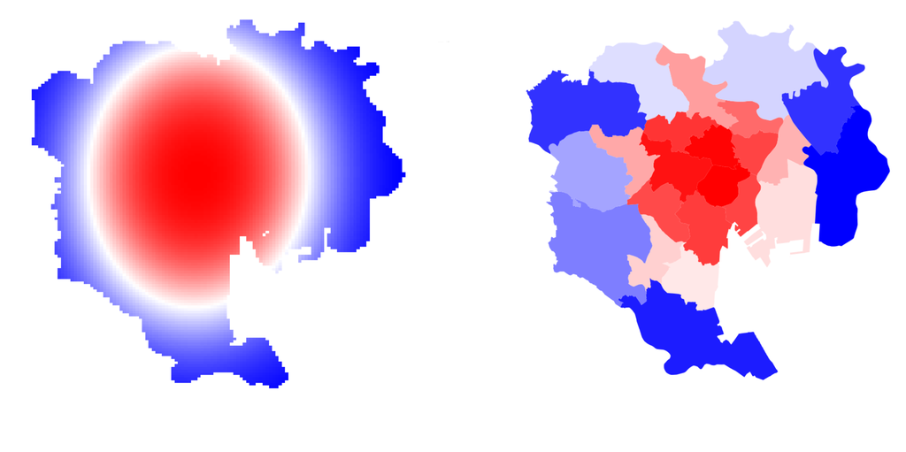

東京23区のToy dataに対して実験

完全にToy data（床面積＝面積，距離＝直線距離）なので，高解像度の250メッシュのケースのほうが，チープな結果に見えてしまう．

このように可視化していくと，実データを使って分析を進めたくなる．